# One-Predictor Linear Model Example

## Graph Posterior(s)

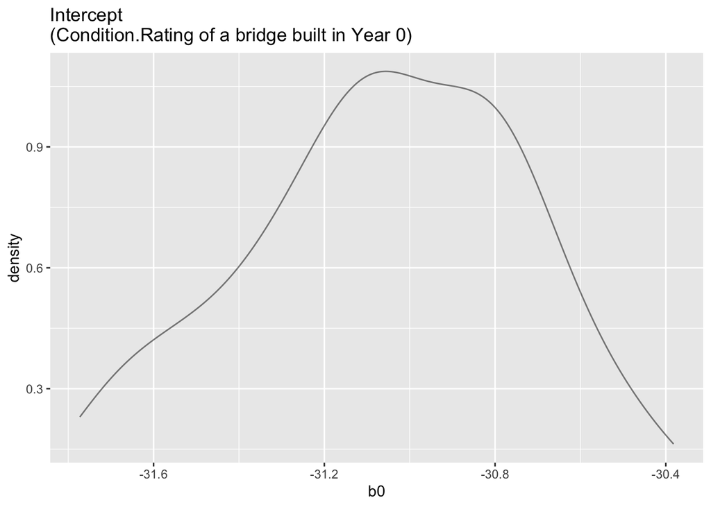

```r
gf_dens(~b0, data = psamp, title = 'Intercept\n(Condition.Rating of a bridge built in Year 0)')
```

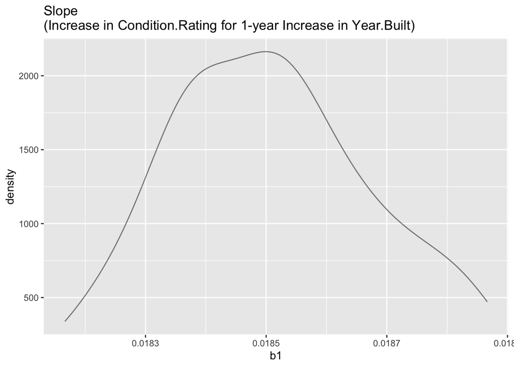

```r
gf_dens(~b1, data = psamp, title = 'Slope\n(Increase in Condition.Rating for 1-year Increase in Year.Built)')
```

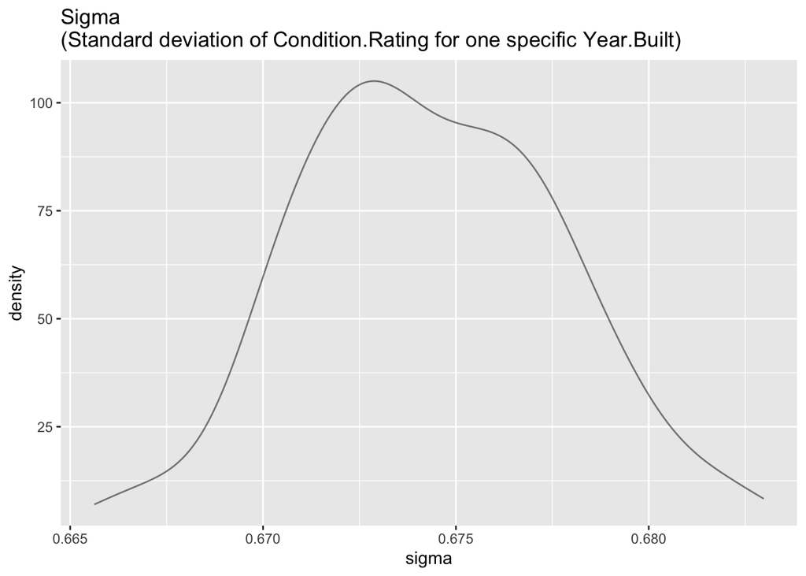

```r
gf_dens(~sigma, data = psamp, title = 'Sigma\n(Standard deviation of Condition.Rating for one specific Year.Built)')
```

## How to Display the Posterior?

What’s this model *doing*? It’s fitting a line to the scatter plot of the data.

### Lines

We might consider drawing the *lines* corresponding to our posterior sample to visualize what the model says about the relationship of age and condition.

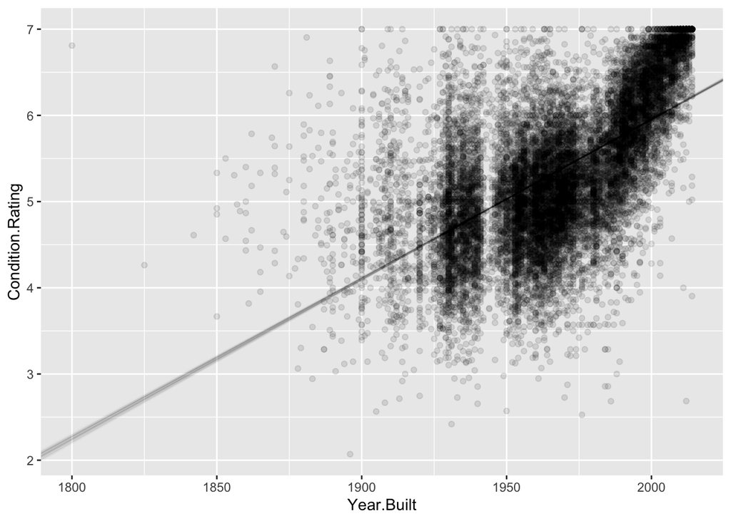

```r
gf_point(Condition.Rating ~ Year.Built,
         data = bridges,
         alpha = 0.1) |>
  gf_abline( # draws "line"s given "a" (slope) and "b" (intercept)
    slope = ~b1, # draws one line for each row of psamp
    intercept = ~b0,
    data = psamp,
    alpha = 0.05, # closer to 0 = more transparent
    linewidth = 0.1 # smaller = thinner
  )
```

### Posterior Predictive Distribution

A posterior predictive distribution would be made up of many fake datasets, each one including `nrow(bridges)` simulated `Condition.Rating` values. And to simulate new datapoints, we’d take into account the posterior for $\sigma$ *as well as* those of the slope and intercept.

```r
psamp <- psamp |>
  # add row numbers to identify each draw from the posterior
  mutate(sim_id = c(1:nrow(psamp))) |>
  rowwise()  |> # one simulation per draw from posteriors
  mutate(
    # mean_condition is the expected response
    # it's a list with one value per row of original data, `bridges`
    mean_condition = list(b0 + b1 * bridges$Year.Built),
    # store predictor data too to make graphs easier later
    year_built = list(bridges$Year.Built)) |>
  mutate(
    # use sigma to simulate how far datapoints are from expected response
    sim_condition = list(mean_condition +
                           rnorm(n = nrow(bridges), mean = 0, sd = sigma))
    ) |>
  unnest(cols = c(year_built, mean_condition, sim_condition)) |>
  ungroup()
```

We now have **100** simulated datasets generated based on our fitted model. The simulated datasets look how we’d expect real data to look, *if the model were true.*

How can we visualize many datasets at once? We can look at just the first 10 datasets to get an idea of what we have done:

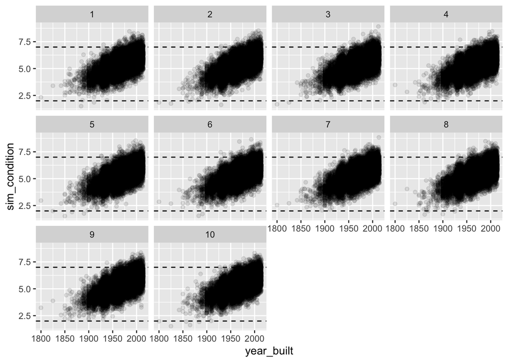

```r
gf_point(sim_condition ~ year_built | sim_id,
         data  = psamp |> filter(sim_id <= 10),
         alpha = 0.1) |>
  # dashed lines show ranges observed in real data
  # (not needed if there are not lower/upper bounds on possible values of response)
  gf_hline(yintercept = 7, linetype = 'dashed') |>
  gf_hline(yintercept = 2, linetype = 'dashed')
```

How does this compare to the actual data?

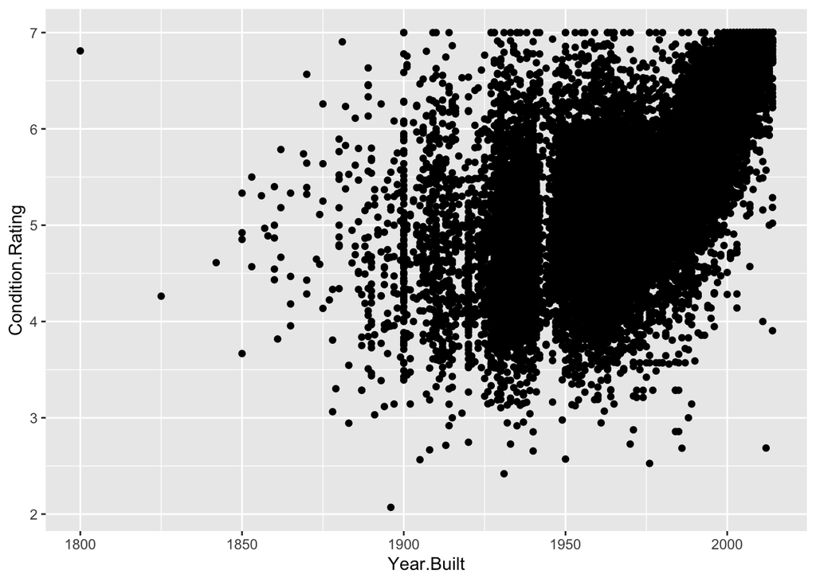

```r
gf_point(Condition.Rating ~ Year.Built, data = bridges)
```

The simulated data are more patternless (aside from the linear trend), and go above the top condition rating of 7. The real data has many more *very old* bridges in *good* condition (simulated data has none) but otherwise does not look terribly different from the real data.

How else could we show “all” the posterior predictive distribution?

One idea is to make a scatter plot where color intensity corresponds to the number of datapoints in each location. We could then overlay the actual data on top.

*Note: this takes a loooong time when the dataset is as large as this one.*

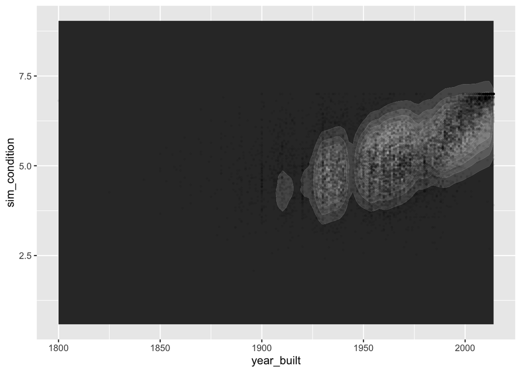

```r
gf_density2d_filled(sim_condition ~ year_built,
                    data  = psamp) |>
  gf_theme(scale_fill_grey('')) |> # use greyscale color palette
  gf_refine(guides(fill = FALSE)) |> # don't show color legend
  # (optional) add the real data
  gf_point(Condition.Rating ~ Year.Built, data =  bridges,
           size = 0.5, alpha = 0.05) # VERY nearly transparent
```

### Intervals

The methods above are preferred – this one is provided for compatibility with frequentist confidence intervals. It may be more familiar but isn’t “better.”

We can also compute *pointwise percentile-based credible intervals* for the response. Say we want a confidence level of 95%, so we want to find the 2.5 and 97.5 percentiles of the model-simulated values. To do this, *for each unique value of the* **PREDICTOR** *of interest*, we find the 0.025 and 0.975 quantiles. Then we can plot the credible intervals for the *expected response (the line)* or *simulated new datapoints* as a shaded region.

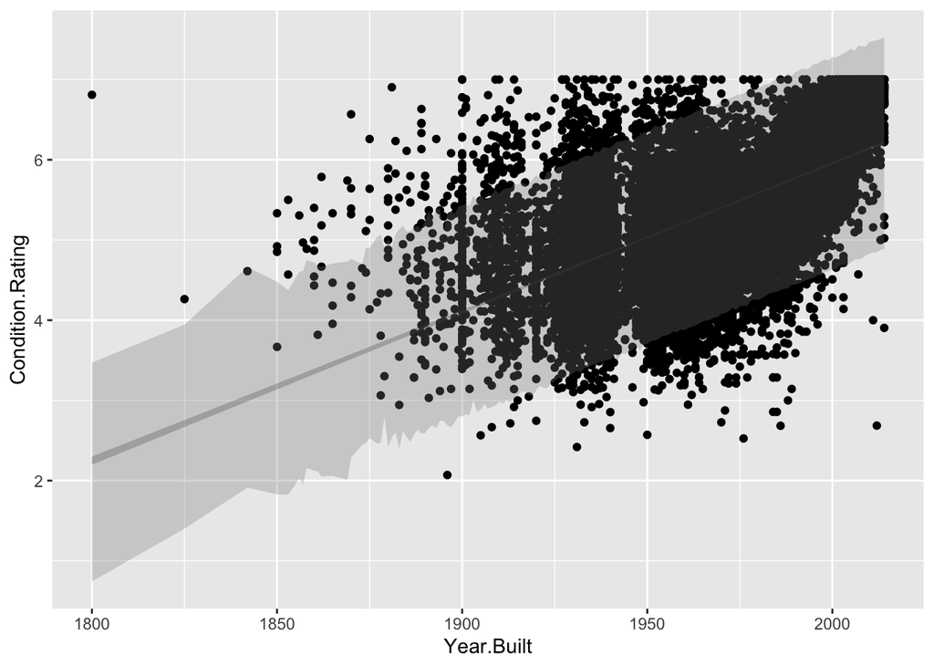

```r
psamp_CIs <- psamp |>
  group_by(year_built) |> # group by unique values of PREDICTOR
  summarise(CrI_line_low = quantile(mean_condition, 0.025),
            CrI_line_high = quantile(mean_condition, 0.975),
            CrI_points_low = quantile(sim_condition, 0.025),
            CrI_points_high = quantile(sim_condition, 0.975))

gf_point(Condition.Rating ~ Year.Built, data = bridges) |>
  gf_ribbon(CrI_line_low + CrI_line_high ~ year_built,
            data  = psamp_CIs, fill = 'grey24',
            inherit = FALSE) |>
  gf_ribbon(CrI_points_low + CrI_points_high ~ year_built,
            data  = psamp_CIs, fill = 'grey54',
            inherit = FALSE)
```